# Lesson Notes: Intro to Functions and Conditionals

Kene David Nwosu

Daniel Camara

Eduardo Araujo

Laure Vancauwenberghe

Ayodele Omotola Lawal

2024-11-19

# 1 Intro

The two main components of the R language are objects and functions. Objects are the data structures that we use to store information, and functions are the tools that we use to manipulate these objects. Paraphrasing [John Chambers](https://statweb.stanford.edu/~jmc4/vitae.html), one of the originators of the R language, everything that “exists” in R is an object, and everything that “happens” is a function.

So far you have mostly used functions written by others. In this lesson, you will learn how to write your own functions.

Writing functions allows you to automate repetitive tasks, improve efficiency and reduce errors in your code.

In this lesson, we will learn the fundamentals of functions with simple examples. Then in a future lesson, we will write more complex functions that can automate large parts of your data analysis workflow.

# 2 Learning objectives

By the end of this lesson, you will be able to:

1. Create and use your own functions in R.
2. Design function arguments and set default values.
3. Use conditional logic like `if`, `else if`, and `else` within functions.
4. Check and validate function arguments to prevent errors.
5. Manage function scope and understand local vs. global variables.
6. Handle vectorized data in functions.
7. Organize and store your custom functions for easy reuse.

# 3 Packages

Run the following code to install and load the packages needed for this lesson:

```r
if (!require(pacman)) install.packages("pacman")
pacman::p_load(tidyverse, here, NHSRdatasets, medicaldata, outbreaks, reactable)
```

## 3.1 Packages

‣ Install and load necessary packages for this lesson.

```r
if (!require(pacman)) install.packages("pacman")
pacman::p_load(tidyverse, here, NHSRdatasets, medicaldata, outbreaks, reactable)
```

## 3.2 Basics of a Function

‣ Learn to create a simple function: **Converting pounds to kilograms**

‣ Define a function named `pounds_to_kg`, by multiplying the input by 0.4536:

```r
pounds_to_kg <- function(pounds){
  kg <- pounds * 0.4536
  return(kg)
}
```

‣ New object in environment of type function.

‣ Use `pounds_to_kg` to convert a value:

```r
pounds_to_kg(200)
```

```
## [1] 90.72
```

‣ Breaking down function structure:

```r
# Slowly build up the function
pounds_to_kg <- function(pounds){
  kg <- pounds * 0.4536
  return(kg)
}
```

‣ **Function creation**: Use `function`, followed by parentheses and braces.

‣ **Arguments**: Define inside parentheses. Example: `pounds`. But can be any name.

‣ **Body**: Code to execute inside braces.

‣ **Returning values**: Use `return` to specify what to return.

‣ **Naming the function**: Store in an object, e.g., `pounds_to_kg`.

‣ We can use the function with named and unnamed arguments:

```r
pounds_to_kg(pounds = 200)
```

```
## [1] 90.72
```

```r
pounds_to_kg(100)
```

```
## [1] 45.36
```

‣ And we can apply function to a vector:

```r
pounds_vec <- c(100, 200, 300)
pounds_to_kg(pounds_vec)
```

```
## [1]  45.36  90.72 136.08
```

‣ To explore the function’s source code, type the function’s name without parentheses:

```r
pounds_to_kg
```

```
## function(pounds){
##   kg <- pounds * 0.4536
##   return(kg)
## }
## <bytecode: 0x000001dd90402978>
```

‣ Or view the function in RStudio with `View`:

```r
View(pounds_to_kg)  # View the pounds_to_kg function
View(reactable)  # View the reactable function
```

### Age Months Function

*(NOTE: Answers are at the bottom of the page. Try to answer the questions yourself before checking.)*

Create a simple function called `years_to_months` that transforms age in years to age in months.

Try it out with `years_to_months(12)`

```r
# Your code here
years_to_months <- function(years){
  month <- years * 12
  return(month)
}

years_to_months(3)
```

‣ Let’s write a more complex function: Converting Fahrenheit to Celsius.

‣ The formula: $C = \frac{5}{9} \times (F - 32)$

```r
fahrenheit_to_celsius <- function(fahrenheit){
  celsius <- ((5/9) * (fahrenheit - 32))
  return(celsius)
}

fahrenheit_to_celsius(32) # Should be 0
```

```
## [1] 0
```

‣ Testing the function on the `airquality` dataset.

```r
airquality |>
  select(Temp) |> # select the Temp column
   mutate(Temp_celsius = fahrenheit_to_celsius(Temp)) # apply the function to the Temp column
```

```
##     Temp Temp_celsius
## 1     67     19.44444
## 2     72     22.22222
## 3     74     23.33333
## 4     62     16.66667
## 5     56     13.33333
## 6     66     18.88889
## 7     65     18.33333
## 8     59     15.00000
## 9     61     16.11111
## 10    69     20.55556
## 11    74     23.33333
## 12    69     20.55556
## 13    66     18.88889
## 14    68     20.00000
```

[output cut: 139 more lines]

Great!

## 3.3 When to Write a Function in R

‣ **Reusability**: Writing functions for repetitive code enhances efficiency.

‣ **Readability**: Descriptive functions clarify code purpose. Though not so obvious with simple functions:

```r
airquality %>%
  mutate(Temp = fahrenheit_to_celsius(Temp))
```

```
##     Ozone Solar.R Wind     Temp Month Day
## 1      41     190  7.4 19.44444     5   1
## 2      36     118  8.0 22.22222     5   2
## 3      12     149 12.6 23.33333     5   3
## 4      18     313 11.5 16.66667     5   4
## 5      NA      NA 14.3 13.33333     5   5
## 6      28      NA 14.9 18.88889     5   6
## 7      23     299  8.6 18.33333     5   7
## 8      19      99 13.8 15.00000     5   8
## 9       8      19 20.1 16.11111     5   9
## 10     NA     194  8.6 20.55556     5  10
## 11      7      NA  6.9 23.33333     5  11
## 12     16     256  9.7 20.55556     5  12
## 13     11     290  9.2 18.88889     5  13
## 14     14     274 10.9 20.00000     5  14
```

[output cut: 139 more lines]

```r
# VS

airquality %>%
  mutate(Temp = Temp * 5 / 9 - 32)
```

```
##     Ozone Solar.R Wind       Temp Month Day
## 1      41     190  7.4  5.2222222     5   1
## 2      36     118  8.0  8.0000000     5   2
## 3      12     149 12.6  9.1111111     5   3
## 4      18     313 11.5  2.4444444     5   4
## 5      NA      NA 14.3 -0.8888889     5   5
## 6      28      NA 14.9  4.6666667     5   6
## 7      23     299  8.6  4.1111111     5   7
## 8      19      99 13.8  0.7777778     5   8
## 9       8      19 20.1  1.8888889     5   9
## 10     NA     194  8.6  6.3333333     5  10
## 11      7      NA  6.9  9.1111111     5  11
## 12     16     256  9.7  6.3333333     5  12
## 13     11     290  9.2  4.6666667     5  13
## 14     14     274 10.9  5.7777778     5  14
```

[output cut: 139 more lines]

‣ **Sharing**: Functions facilitate code sharing, through packages or scripts. We’ll talk about sharing options later.

‣ **SIDE-NOTE** Data Frame and Plot functions are among the most useful. For example, this function creates an epidemic curve from a dataset:

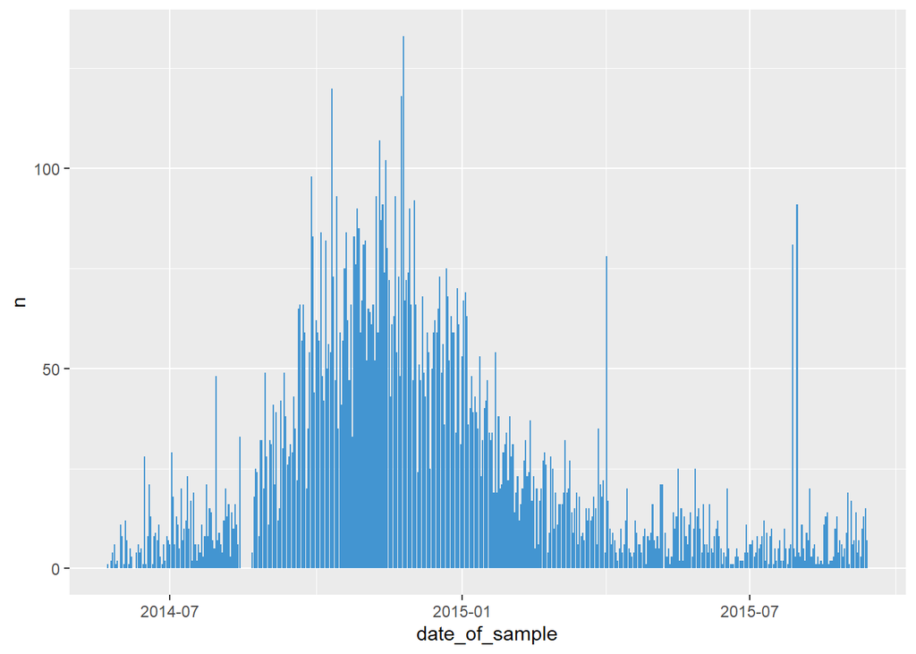

```r
# Function to plot an epidemic curve
plot_epidemic_curve <- function(data, date_column) {
  data %>%
    count({{ date_column }}) %>%
    complete({{ date_column }} := seq(min({{ date_column }}),
                                      max({{ date_column }}), by="day")) %>%
    ggplot(aes(x = {{ date_column }}, y = n)) +
    geom_col(fill = "#4395D1")
}

# Example usage
plot_epidemic_curve(outbreaks::ebola_sierraleone_2014, date_of_sample)
```

‣ We’ll explore such in a future lesson. For now, focusing on vector manipulation functions to give you a solid foundation.

### Celsius to Fahrenheit Function

Create a function named `celsius_to_fahrenheit` that converts temperature from Celsius to Fahrenheit. Here is the formula for this conversion:

$$Fahrenheit = Celsius * 1.8 + 32$$

```r
# Your code here
celsius_to_fahrenheit <- function(celsius){
  fahrenheit <- celsius*1.8+32
  return(fahrenheit)
}
```

Then test your function on the `temp` column of the built-in `beaver1` dataset in R:

```r
beaver1 %>%
  select(temp) %>%
  mutate(temp_fahrenheit = celsius_to_fahrenheit(temp)) %>%
  head()
```

## 3.4 Functions with Multiple Arguments

‣ Functions typically have multiple arguments. Let’s see a function with three arguments.

‣ `calculate_calories`, to calculate calories from macronutrients.

```r
calculate_calories <- function(carb_grams, protein_grams, fat_grams){
  result <- (carb_grams * 4) + (protein_grams * 4) + (fat_grams * 9)
  return(result)
}


calculate_calories(carb_grams = 50, protein_grams = 25, fat_grams = 10)
```

```
## [1] 390
```

‣ Without all arguments, the function yields an error.

```r
calculate_calories(carb_grams = 50, protein_grams = 25)
```

```r
calculate_calories <- function(carb_grams, protein_grams, fat_grams) {
  result <- (carb_grams * 4) + (protein_grams * 4) + (fat_grams * 9)
  return(result)
}

calculate_calories(50, 25)
```

```
## Error in calculate_calories(50, 25): argument "fat_grams" is missing, with no default
```

‣ We can make **all** arguments optional with default values.

```r
calculate_calories <- function(carb_grams = 0, protein_grams=0, fat_grams = 0) {
  result <- (carb_grams * 4) + (protein_grams * 4) + (fat_grams * 9)
  return(result)
}
```

‣ Now we can call the function with no or some arguments.

```r
calculate_calories()
```

```
## [1] 0
```

```r
calculate_calories(carb_grams= 50, protein_grams = 25)
```

```
## [1] 300
```

### BMI Function

Create a function named `calc_bmi` that calculates the Body Mass Index (BMI) for one or more individuals. Keep in mind that BMI is calculated as weight in kg divided by the square of the height in meters. Therefore, this function requires two mandatory arguments: weight and height.

```r
# Your code here
calc_bmi <- function(weight=0, height=0){
  bmi <- weight/((height/100)^2)
  return(bmi)
}
```

Then, apply your function to the `medicaldata::smartpill` dataset to calculate the BMI for each person:

```r
medicaldata::smartpill |>
  as_tibble() |>
  select(Weight, Height) |>
  mutate(BMI = calc_bmi(Weight, Height))
```

## 3.5 Understanding Scope in R

‣ **Scope** refers to the **visibility of variables** and objects within different parts of your R code.

‣ Objects within a function have **local scope** (as opposed to **global scope**) and are not accessible outside the function.

‣ Imagin we wrote the `pounds_to_kg` function like this:

```r
pounds_to_kg <- function(pounds) {
  kg <- pounds * 0.4536
}
```

‣ May be tempted to try to access the `kg` variable outside of the function, but you’ll get an error:

```r
pounds_to_kg(50)
kg
```

```
## Error in eval(expr, envir, enclos): object 'kg' not found
```

‣ To use a value generated within a function, it must be **returned** by the function.

```r
pounds_to_kg <- function(pounds) {
  kg <- pounds * 0.4536
  return(kg)
}
```

‣ Store the function’s result in a global variable to access it.

```r
kg <- pounds_to_kg(50)
  # store the output of pounds_to_kg(50) in a global object, kg
kg
```

```
## [1] 22.68
```

## 3.6 Intro to Conditionals: `if`, `else if` and `else`

‣ Conditionals control the flow of code execution, especially useful in functions.

‣ R implements conditionals using `if`, `else`, and `else if` statements.

‣ `if` is used to run code only if a specific condition is true.

‣ Structure of an `if` statement:

```r
if (condition) {
  # some code we want to run
}         # if condition true, run code body
```

‣ Example: Converting temperature from Celsius to Fahrenheit.

```r
celsius <- 20
convert_to <- "fahrenheit"

# if convert_to is "fahrenheit", create fahrenheit, as c * 9/5 + 32, then print
if (convert_to == "fahrenheit"){
  fahrenheit <- celsius * 9/5 + 32
  print(fahrenheit)
}
```

```
## [1] 68
```

‣ If `convert_to` is `"fahrenheit"`, the code body is executed, and if not, it is skipped.

```r
celsius <- 20
convert_to <- "kelvin"

# if convert_to is "fahrenheit", create fahrenheit, as c * 9/5 + 32, then print
if (convert_to == "fahrenheit"){
  fahrenheit <- celsius * 9/5 + 32
  print(fahrenheit)
}
```

‣ Add an `else` clause to handle the case where `convert_to` is not `"fahrenheit"`.

```r
celsius <- 20
convert_to <- "kelvin"

# add else clause to print original celsius value
if (convert_to == "fahrenheit"){
  fahrenheit <- celsius * 9/5 + 32
  print(fahrenheit)
} else {
  print(celsius)
}
```

```
## [1] 20
```

‣ Use `else if` to check multiple specific conditions.

```r
celsius <- 20
convert_to <- "kelvin"

if (convert_to == "fahrenheit") {
  fahrenheit <- (celsius * 9/5) + 32
  print(fahrenheit)
} else if (convert_to == "kelvin") {
  kelvin <- celsius + 273.15
  print(kelvin)
} else {
  print(celsius)
}
```

```
## [1] 293.15
```

‣ Code handles three scenarios: converting to Fahrenheit, Kelvin, or keeping Celsius.

‣ Can have as many `else if` statements as you need, but can only have one `else` statement attached to an `if` statement.

‣ Finally, we can encapsulate this logic into a function.

```r
celsius_convert <- function(celsius, convert_to){
  if (convert_to == "fahrenheit"){
  out <- (celsius * 9/5) + 32
} else if (convert_to == "kelvin"){
  out <- celsius + 273.15
} else {
  out <-  celsius
}
  return(out)
}
```

‣ Let’s test the function:

```r
celsius_convert(20, "fahrenheit")
```

```
## [1] 68
```

```r
celsius_convert(20, "kelvin")
```

```
## [1] 293.15
```

‣ One problem: silent failure. If we pass in an invalid value for `convert_to`, the function fails without an informative error message.

```r
celsius_convert(20, "celsius")
```

```
## [1] 20
```

```r
celsius_convert(20, "foo")
```

```
## [1] 20
```

‣ Will need to add some error handling to the function.

### Debugging a Function with Conditional Logic

A function named `check_negatives` is designed to analyze a vector of numbers in R and print a message indicating whether the vector contains any negative numbers. However, the function currently has syntax errors.

```r
check_negatives <- function(numbers) {
   x <- numbers
  if (any(x < 0)) {
    print("x contains negative numbers")
    }
  else {
    print("x does not contain negative numbers")
  }
}
```

Identify and correct the syntax errors in the `check_negatives` function. After correcting the function, test it with the following vectors to ensure it works correctly: 1. `c(8, 3, -2, 5)` 2. `c(10, 20, 30, 40)`

```r
x1 <- c(8, 3, -2, 5)
x2 <- c(10, 20, 30, 40)

check_negatives(x1)
```

```
## Error in check_negatives(x1): could not find function "check_negatives"
```

```r
check_negatives(x2)
```

```
## Error in check_negatives(x2): could not find function "check_negatives"
```

## 3.7 Argument Checking with Conditionals

‣ Argument checking is crucial in R functions to ensure inputs are sensible.

‣ Without checks, functions may return incorrect results, fail silently, or fail with an uninformative error message.

‣ Example: Using `celsius_convert()` function for temperature conversion.

```r
celsius_convert(30, "centigrade")
```

```
## [1] 30
```

‣ **Issue**: Fails silently when `convert_to` is not a valid temperature scale.

‣ **Solution**: Implement argument checking using the `stop()` function in R.

‣ Example: Validate `convert_to` argument. We’ll write them out first, then integrate them into the function.

```r
convert_to <- "bad scale"

# if convert_to is not in fahrenheit, or kelvin, stop() with error message
if (!convert_to %in% c("fahrenheit", "kelvin")){
  stop("convert to must be one of 'fahrenheit; or 'kelvin'")
}
```

‣ **Integration into `celsius_convert()` function**:

```r
celsius_convert <- function(celsius, convert_to){

  # Checking validity
  if (!convert_to %in% c("fahrenheit", "kelvin", "centigrade")){
  stop("convert to must be one of 'fahrenheit; or 'kelvin'")
  }

  # Converting value
  if (convert_to == "fahrenheit"){
  out <- (celsius * 9/5) + 32
} else if (convert_to == "kelvin"){
  out <- celsius + 273.15
} else if (convert_to == "centigrade"){
  out <- celsius
}
  return(out)
}
```

‣ No longer a need for `else`, since `stop()` will halt execution if `convert_to` is not valid.

```r
celsius_convert(30, "centigrade")
```

**PRO TIP**

‣ **Balancing Argument Checking**: Checking should ensure reliability without overcomplicating the code or impacting performance.

‣ You will develop a sense of the right amount of checking through experience and examining others’ code. For now, note that it is usually good to err on the side of more checking.

### Argument Checking Practice

Consider the `calculate_calories` function we wrote earlier:

```r
calculate_calories <- function(carb_grams = 0, protein_grams = 0, fat_grams = 0) {
  result <- (carb_grams * 4) + (protein_grams * 4) + (fat_grams * 9)
  return(result)
}
```

Write a function called `calculate_calories2()` that is the same as `calculate_calories()` except that it checks if the `carb_grams`, `protein_grams`, and `fat_grams` arguments are numeric. If any of them are not numeric, the function should print an error message using the `stop()` function.

```r
calculate_calories2 <- function(carb_grams = 0, protein_grams = 0, fat_grams = 0) {

  # your code here
  if (!is.numeric(c(carb_grams, protein_grams, fat_grams))){
    stop("All arguments must be numeric")
}
  result <- (carb_grams * 4) + (protein_grams * 4) + (fat_grams * 9)
  return(result)
}

calculate_calories2("five", 20, 30)
```

## 3.8 Vectorized Conditionals

‣ Consider this attempt at a function `classify_temp` for classifying temperature readings.

```r
classify_temp <- function(temp) {
  if (temp < 35) {
    print("hypothermia")
  } else if (temp >= 35 & temp <= 37) {
    print("normal")
  } else if (temp > 37) {
    print("fever")
  }
}
```

‣ Works for a single value, but not for vectors.

```r
classify_temp(36)
```

```
## [1] "normal"
```

```r
temp_vec <- c(36, 37, 38)
classify_temp(temp_vec)  # This won't work correctly
```

```
## Error in if (temp < 35) {: the condition has length > 1
```

‣ For conditional statements for vectors, we therefore use `ifelse` or `dplyr::case_when`.

```r
classify_temp <- function(temp){
 out <-  ifelse(temp < 35, "hypothermia",
                ifelse(temp >= 35 & temp <= 37, "normal",
                       ifelse(temp > 37, "fever", "NA")))
 return(out)
}
      # ifelse temp less than 35, return "hypothermia"
      # nested ifelse temp between 35 and 37, return "normal"
      # nested ifelse temp greater than 37, return "fever"

classify_temp(temp_vec)  # Works for vector
```

```
## [1] "normal" "normal" "fever"
```

‣ `dplyr::case_when` is a more readable alternative.

```r
classify_temp <- function(temp) {
  case_when(
    temp < 35 ~ "hypothermia",
    temp >= 35 & temp <= 37 ~ "normal",
    temp > 37 ~ "fever",
    TRUE ~ NA_character_
  )
}

classify_temp(temp_vec)  # This also works as expected
```

```
## [1] "normal" "normal" "fever"
```

‣ This function can be seamlessly integrated with data frames.

```r
NHSRdatasets::synthetic_news_data %>%
  select(temp) %>%
  mutate(temp_classif = classify_temp(temp))
```

```
## # A tibble: 1,000 × 2
##     temp temp_classif
##    <dbl> <chr>
##  1  36.8 normal
##  2  35   normal
##  3  36.2 normal
##  4  36.9 normal
##  5  36.4 normal
##  6  35.3 normal
##  7  35.6 normal
##  8  37.2 fever
##  9  35.5 normal
## 10  35.3 normal
## # ℹ 990 more rows
```

### Practice Classifying Dosage of Isoniazid

Let’s apply this knowledge to a practical case. Consider the following attempt at writing a function that calculates dosages of the drug isoniazid for adults weighing more than 30kg:

```r
calculate_isoniazid_dosage <- function(weight) {
  if (weight < 30) {
    stop("Weight must be at least 30 kg.")
  } else if (weight <= 35) {
    return(150)
  } else if (weight <= 45) {
    return(200)
  } else if (weight <= 55) {
    return(300)
  } else if (weight <= 70) {
    return(300)
  } else {
    return(300)
  }
}
```

This function fails with a vector of weights. Your task is to write a new function `calculate_isoniazid_dosage2()` that can handle vector inputs. To ensure all weights are above 30kg, you’ll use the `any()` function within your error checking.

Here’s a scaffold to get you started:

```r
calculate_isoniazid_dosage2 <- function(weight) {
  if (any(weight < 30)) stop("Weights must all be at least 30 kg.")

  # Your code here
  {
    out <- ifelse(weight <= 35, 150,
          ifelse(weight <= 45, 200,
                 ifelse(weight <= 55, 300,
                        ifelse(weight <= 70, 300, 300))))
    return(out)

  }
  return(out)
}

calculate_isoniazid_dosage2(c(30, 40, 50, 100))
```

```
## [1] 150 200 300 300
```

# 4 Storing your functions for future use

To store your functions in R for future use, you can save them in a script or package. Here’s how:

### 1. Save Functions in an R Script

‣ **Create a script file**:

1. Open RStudio (or any text editor).
2. Write your functions in a new script file (e.g., my_functions.R).
3. Save the file in a desired location.

‣ **Load the script**: To use the functions in future sessions, load the script using:

```
source(("path/to/my_functions.R"))
```

‣ **Example**:

```r
# Save this in my_functions.R
calculate_calories <- function(carb_grams, protein_grams, fat_grams) {
  (carb_grams * 4) + (protein_grams * 4) + (fat_grams * 9)
}
```

Then load the file:

```r
source(here("global/functions/my_functions.R"))
calculate_calories(10, 5, 2)
```

```
## [1] 78
```

### 2. Save Functions in an R Data File Save function objects:

‣ **Save function objects**:

```r
save(calculate_calories2, calc_bmi, pounds_to_kg, years_to_months, celsius_convert, calculate_isoniazid_dosage2, celsius_to_fahrenheit, fahrenheit_to_celsius, classify_temp2, file = "my_functions.RData")
```

‣ **Load the file**: In future sessions, you can load the .RData file:

```r
load("my_functions.RData")

temp_vec <- c(36, 37, 38)
classify_temp2(temp_vec)
```

```
## [1] "normal" "normal" "fever"
```

### 3. Create a Custom R Package:

If you plan to use your functions frequently across multiple projects, creating a package is a good approach.

Building packages doesn’t have to be intimidating! Thanks to the tidyverse team, getting started is simple with RStudio and the **devtools** and **usethis** packages. In this [one-hour presentation](https://www.youtube.com/live/EpTkT6Rkgbs?si=rQKwbSDakAFcGilK) , you’ll learn the fundamentals of R package development and gain the confidence to start building your own packages!

‣ Click here for **slides**.

‣ Click here for **source code**

‣ Click here for more information on **devtools**

‣ Click here for more information on **usethis**

‣ Click here for more resources on **R Packages book**

‣ Learn how to create a package, the fundamental unit of shareable, reusable, and reproducible R code by reading and studying the 2nd edition of [R Packages](https://r-pkgs.org/), by Hadley Wickham and Jennifer Bryan

‣ This [youtube video: How to Create Your Own Package in RStudio](https://youtu.be/rsQoEgWeJMk?si=j2B5SY_k_4kVqVHT) is also helpful in creating your own package and storing in GitHub.

### 4. Store Functions in the Global Environment

You can also define functions in your `.Rprofile` file, so they are available every time you start R:

‣ Edit your `.Rprofil`e:

```r
file.edit("~/.Rprofile")
```

‣ Add your function definitions to the file.

‣ Save and restart your R session to access the functions.

**Choose the method that best fits your workflow and the frequency of use for your functions!**

# 5 Answer Key

### Age Months Function

```r
years_to_months <- function(years) {
  months <- years * 12
  return(months)
}

# Test
years_to_months(12)
```

```
## [1] 144
```

### Celsius to Fahrenheit Function

```r
celsius_to_fahrenheit <- function(celsius) {
  fahrenheit <- celsius * 1.8 + 32
  return(fahrenheit)
}

# Test
beaver1 %>%
  select(temp) %>%
  mutate(Fahrenheit = celsius_to_fahrenheit(temp))
```

```
##      temp Fahrenheit
## 1   36.33     97.394
## 2   36.34     97.412
## 3   36.35     97.430
## 4   36.42     97.556
## 5   36.55     97.790
## 6   36.69     98.042
## 7   36.71     98.078
## 8   36.75     98.150
## 9   36.81     98.258
## 10  36.88     98.384
## 11  36.89     98.402
## 12  36.91     98.438
## 13  36.85     98.330
## 14  36.89     98.402
```

[output cut: 100 more lines]

### BMI Function

```r
calc_bmi <- function(weight, height) {
  bmi <- weight / (height^2)
  return(bmi)
}

# Test
library(medicaldata)
medicaldata::smartpill %>%
  as_tibble() %>%
  select(Weight, Height) %>%
  mutate(BMI = calc_bmi(Weight, Height))
```

```
## # A tibble: 95 × 3
##    Weight Height     BMI
##     <dbl>  <dbl>   <dbl>
##  1  102.    183. 0.00305
##  2  102.    180. 0.00314
##  3   68.0   180. 0.00209
##  4   69.9   175. 0.00227
##  5   44.9   152. 0.00193
##  6   94.8   185. 0.00276
##  7   86.2   188. 0.00244
##  8   76.2   165. 0.00280
##  9   74.4   173. 0.00249
## 10   64.9   170. 0.00224
## # ℹ 85 more rows
```

```r
calculate_calories <- function(carb_grams, protein_grams, fat_grams, ...) {
  result <- (carb_grams * 4) + (protein_grams * 4) + (fat_grams * 9)
  result_formatted <- format(result, ...)
  return(result)
}
```

### Debugging a Function with Conditional Logic

```r
check_negatives <- function(numbers) {
  if (any(numbers < 0)) {
    print("x contains negative numbers")
  } else {
    print("x does not contain negative numbers")
  }
}

# Test
check_negatives(c(8, 3, -2, 5))
```

```
## [1] "x contains negative numbers"
```

```r
check_negatives(c(10, 20, 30, 40))
```

```
## [1] "x does not contain negative numbers"
```

### Argument Checking Practice

```r
calculate_calories2 <- function(carb_grams = 0, protein_grams = 0, fat_grams = 0) {

  if (!is.numeric(carb_grams)) {
    stop("carb_grams must be numeric")
  }

  if (!is.numeric(protein_grams)) {
    stop("protein_grams must be numeric")
  }

  if (!is.numeric(fat_grams)) {
    stop("fat_grams must be numeric")
  }


  result <- (carb_grams * 4) + (protein_grams * 4) + (fat_grams * 9)
  return(result)
}
```

### Practice Classifying Dosage of Isoniazid

```r
calculate_isoniazid_dosage2 <- function(weight) {
  if (any(weight < 30)) stop("Weights must all be at least 30 kg.")

  dosage <- case_when(
    weight <= 35 ~ 150,
    weight <= 45 ~ 200,
    weight <= 55 ~ 300,
    weight <= 70 ~ 300,
    TRUE ~ 300
  )
    return(dosage)
}

calculate_isoniazid_dosage2(c(30, 40, 50, 100))
```

```
## [1] 150 200 300 300
```

# 6 References

Some material in this lesson was adapted from the following sources:

‣ Barnier, Julien. “Introduction à R et au tidyverse.” Accessed May 23, 2022. https://juba.github.io/tidyverse

‣ Wickham, Hadley; Grolemund, Garrett. “R for Data Science.” Accessed May 25, 2022. https://r4ds.had.co.nz/

‣ Wickham, Hadley; Jennifer Bryan. “R Packages (2e).” Accessed Nov 20, 2024.[R Packages (2e)](https://r-pkgs.org/)